# A beautiful report

Quarto demo for the DVIZ course

Author

Teresa Kubacka

Published

April 24, 2023

Abstract

This document summarizes the basic functionalities of typesetting with Quarto

# Typesetting with Jupyter and Quarto

For documentation, see: [Quarto User Guide](https://quarto.org/docs/guide/) and [Reference](https://quarto.org/docs/reference/).

In the command line:

Use:

```
quarto preview notebookname.ipynb
```

to live-preview the document.

Use:

```
quarto render notebookname.ipynb --to html
```

to render the html.

## Front-matter

- `execute`: should all the cells be executed upon rendering
- `code-fold`: all code shown in folded cells
- `echo`: disable code render
- `self-contained`: all the images are embedded in the html
- `toc`: enable table of contents; the levels can be further specified
- `theme`: one of the [Bootswatch](https://bootswatch.com/) themes. A customized css file can also be specified.

## Code

We can have collapsible code snippets

**Click here to see the chart styling**

```python
species_styles = {
    'Adelie': {'color': 'tomato', 's': 100, 'alpha': 0.5},
    'Chinstrap': {'color': 'dodgerblue', 'marker': 'v'},
    'Gentoo': {'color': 'darkgray', 'edgecolor':'black'}
}
```

I can hide some code cells:

And some other code cells I can show:

```python
data_agg = data.groupby(['species','island','sex'])['body_mass_g'].count().rename('count').reset_index()
data_agg2 = data_agg.groupby('species')['count'].sum().reset_index()
```

## Printing tables

Below is a simple table:

Table 1: This is a table with aggregated data.

|  | species | count |
| --- | --- | --- |
| 0 | Adelie | 146 |
| 1 | Chinstrap | 68 |
| 2 | Gentoo | 119 |

We can change the width of the cell where the table output is rendered:

Table 2: This is a sample of a long table

|  | species | island | bill_length_mm | bill_depth_mm | flipper_length_mm | body_mass_g | sex |
| --- | --- | --- | --- | --- | --- | --- | --- |
| 0 | Adelie | Torgersen | 39.1 | 18.7 | 181.0 | 3750.0 | Male |
| 1 | Adelie | Torgersen | 39.5 | 17.4 | 186.0 | 3800.0 | Female |
| 2 | Adelie | Torgersen | 40.3 | 18.0 | 195.0 | 3250.0 | Female |
| 3 | Adelie | Torgersen | NaN | NaN | NaN | NaN | NaN |
| 4 | Adelie | Torgersen | 36.7 | 19.3 | 193.0 | 3450.0 | Female |

Both tables can be referenced and are rendered to links: Table 1 and Table 2

## Plotly figures

Let’s make a plotly chart. This will be Figure 1.

[interactive chart not shown]

Figure 1: The figure illustrates how many penguins in each species were measured.

## Matplotlib

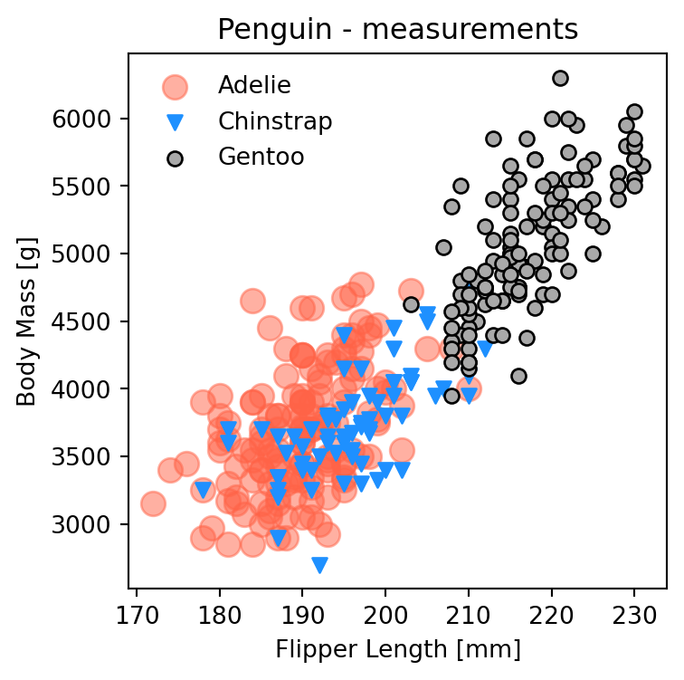

Figure 2: Penguin sizes per species.

## Other fancy things

### Embedding images

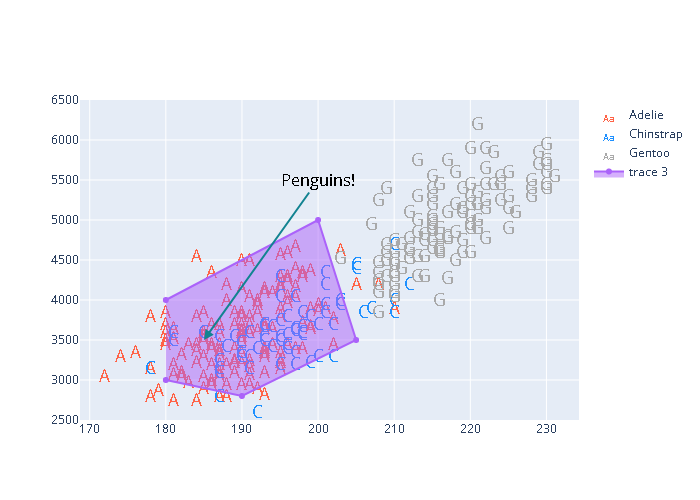

That’s what we did last week

### Embedding iframes and arbitrary html content

[interactive chart not shown]

Figure 3: Iframe.

### Notes and warnings

We can have various types of notes:

**This is a note that can be expanded**

You can change the callout to:

- `.callout-note`
- `.callout-tip`
- `.callout-important`
- `.callout-caution`
- `.callout-warning`

With `collapse` flag you toggle the collapse behavior. You can switch the icon on and off using the `icon` flag. You can set these parameters per cell of in front matter globally.

### Writing on margins

We can write on the margins:

[output not shown]

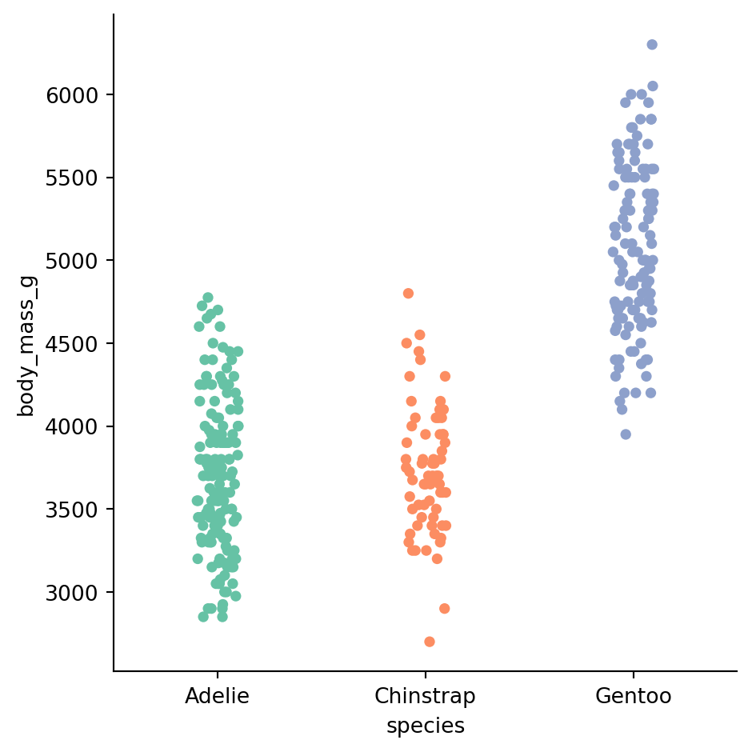

Figure 4: Body mass per species.

This is sucha a nice seaborn chart with pastel colors

We can also print a table in the main field and insert a chart on the margin:

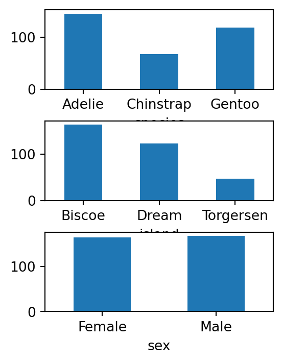

Figure 5: Penguin count statistics.

|  | species | island | sex | count |
| --- | --- | --- | --- | --- |
| 0 | Adelie | Biscoe | Female | 22 |
| 1 | Adelie | Biscoe | Male | 22 |
| 2 | Adelie | Dream | Female | 27 |
| 3 | Adelie | Dream | Male | 28 |
| 4 | Adelie | Torgersen | Female | 24 |
| 5 | Adelie | Torgersen | Male | 23 |
| 6 | Chinstrap | Dream | Female | 34 |
| 7 | Chinstrap | Dream | Male | 34 |
| 8 | Gentoo | Biscoe | Female | 58 |
| 9 | Gentoo | Biscoe | Male | 61 |

I can also add asides. Adding more text for this cell to be longer. More text. More text. More text. More text. More text. More text. More text. More text. More text. More text. More text. More text. More text. More text. More text. More text. More text. More text. More text. More text. More text. More text that has a different color

This is a span that has the class aside which places it in the margin without a footnote number.

### Citing bibliography

We can also cite bibliography. Use a reference manager like Zotero or Jabref to generate a .bib file with citations. You can also create the entries by hand - they are following a BibTex format. You can also use a tool like https://www.bibme.org/bibtex to generate an entry in the .bib file following an URL.

Citing the penguins (Allisonhorst 2020)

(TK 2021)

The end.

## References

Allisonhorst. 2020. “Allisonhorst/Palmerpenguins: A Great Intro Dataset for Data Exploration & Visualization (Alternative to Iris).” *GitHub*. https://github.com/allisonhorst/palmerpenguins.

TK. 2021. “New Entry.”